# Chapter 6: Linear Model Selection and Regularization

Solutions to Exercises

January 23, 2016

## CONCEPTUAL

> EXERCISE 1:

**Part a)**

Best subset will have the smallest train RSS because the models will optimize on the training RSS and best subset will try every model that forward and backward selection will try.

**Part b)**

The best test RSS model could be any of the three. Best subset could easily overfit if the data has large $p$ predictors relative to $n$ observations. Forward and backward selection might not converge on the same model but try the same number of models and hard to say which selection process would be better.

**Part c)**

- 1. TRUE
- 2. TRUE
- 3. FALSE
- 4. FALSE
- 22. FALSE

> EXERCISE 2:

**Part a)**

3. is TRUE - lasso puts a budget constraint on least squares (less flexible)

**Part b)**

3. is TRUE - ridge also puts a budget constraint on least squares (less flexible)

**Part c)**

2. is TRUE - a non-linear model would be more flexible and have higher variance, less bias

> EXERCISE 3:

**Part a)**

4. is TRUE - as $s$ is increased, there is less and less constraint on the model and it should always have a better training error (if $s$ is increased to $s'$, then the best model using a budget of $s$ would be included when using a budget of $s'$)

**Part b)**

2. is TRUE - test error will improve (decrease) to a point and then will worsen (increase) as constraints loosen and model overfits

**Part c)**

3. is TRUE - variance always increases with fewer constraints

**Part d)**

4. is TRUE - bias always decreases with more model flexibility

**Part e)**

22. is TRUE - the irreducible error is a constant value, not related to model selection

> EXERCISE 4:

This problem is similar to Excercise 3, but for ridge instead of lasso and using $\lambda$ instead of $s$. For each question part, ridge and lasso should be the same directionally except that increasing $\lambda$ puts a heavier penalty in the equation, equivalent to reducing the budget $s$, so the answers to Exercise 4 should be flipped (horizontally) from answers in Exercise 3.

**Part a)**

3. is TRUE - training error increases steadily

**Part b)**

2. is TRUE - test error will decrease initially and then increase

**Part c)**

4. is TRUE - variance always decrease with more constraints

**Part d)**

3. is TRUE - bias always increase with less model flexibility

**Part e)**

22. is TRUE - the irreducible error is a constant value, not related to model selection

> EXERCISE 5:

**Part a)**

Ridge: minimize $(y_1 - \hat\beta_1x_{11} - \hat\beta_2x_{12})^2 + (y_2 - \hat\beta_1x_{21} - \hat\beta_2x_{22})^2 + \lambda (\hat\beta_1^2 + \hat\beta_2^2)$

**Part b)**

**Step 1:** Expanding the equation from Part a:

$(y_1 - \hat\beta_1 x_{11} - \hat\beta_2 x_{12})^2 + (y_2 - \hat\beta_1 x_{21} - \hat\beta_2 x_{22})^2 + \lambda (\hat\beta_1^2 + \hat\beta_2^2) \\ = (y_1^2 + \hat\beta_1^2 x_{11}^2 + \hat\beta_2^2 x_{12}^2 - 2 \hat\beta_1 x_{11} y_1 - 2 \hat\beta_2 x_{12} y_1 + 2 \hat\beta_1 \hat\beta_2 x_{11} x_{12}) \\ + (y_2^2 + \hat\beta_1^2 x_{21}^2 + \hat\beta_2^2 x_{22}^2 - 2 \hat\beta_1 x_{21} y_2 - 2 \hat\beta_2 x_{22} y_2 + 2 \hat\beta_1 \hat\beta_2 x_{21} x_{22}) \\ + \lambda \hat\beta_1^2 + \lambda \hat\beta_2^2$

**Step 2:** Taking the partial deritive to $\hat\beta_1$ and setting equation to 0 to minimize:

$\frac{\partial }{\partial \hat\beta_1}: (2\hat\beta_1x_{11}^2-2x_{11}y_1+2\hat\beta_2x_{11}x_{12}) + (2\hat\beta_1x_{21}^2-2x_{21}y_2+2\hat\beta_2x_{21}x_{22}) + 2\lambda\hat\beta_1 = 0$

**Step 3:** Setting $x_{11}=x_{12}=x_1$ and $x_{21}=x_{22}=x_2$ and dividing both sides of the equation by 2:

$(\hat\beta_1x_1^2-x_1y_1+\hat\beta_2x_1^2) + (\hat\beta_1x_2^2-x_2y_2+\hat\beta_2x_2^2) + \lambda\hat\beta_1 = 0$

$\hat\beta_1 (x_1^2+x_2^2) + \hat\beta_2 (x_1^2+x_2^2) + \lambda\hat\beta_1 = x_1y_1 + x_2y_2$

**Step 4:** Add $2\hat\beta_1x_1x_2$ and $2\hat\beta_2x_1x_2$ to both sides of the equation:

$\hat\beta_1 (x_1^2 + x_2^2 + 2x_1x_2) + \hat\beta_2 (x_1^2 + x_2^2 + 2x_1x_2) + \lambda\hat\beta_1 = x_1y_1 + x_2y_2 + 2\hat\beta_1x_1x_2 + 2\hat\beta_2x_1x_2 \\ \hat\beta_1 (x_1 + x_2)^2 + \hat\beta_2 (x_1 + x_2)^2 + \lambda\hat\beta_1 = x_1y_1 + x_2y_2 + 2\hat\beta_1x_1x_2 + 2\hat\beta_2x_1x_2$

**Step 5:** Because $x_1+x_2=0$, we can eliminate the first two terms:

$\lambda\hat\beta_1 = x_1y_1 + x_2y_2 + 2\hat\beta_1x_1x_2 + 2\hat\beta_2x_1x_2$

**Step 6:** Similarly by taking the partial deritive to $\hat\beta_2$, we can get the equation:

$\lambda\hat\beta_2 = x_1y_1 + x_2y_2 + 2\hat\beta_1x_1x_2 + 2\hat\beta_2x_1x_2$

$\lambda\hat\beta_1 = \lambda\hat\beta_2$

$\hat\beta_1 = \hat\beta_2$

**Part c)**

Lasso: minimize $(y_1 - \hat\beta_1x_{11} - \hat\beta_2x_{12})^2 + (y_2 - \hat\beta_1x_{21} - \hat\beta_2x_{22})^2 + \lambda (|\hat\beta_1| + |\hat\beta_2|)$

**Part d)**

Replacing the constraint term from Part b, the derivative term to $\beta$ is:

$\frac{\partial }{\partial \hat\beta} (\lambda |\beta|): \lambda\frac{|\beta|}{\beta}$

Following through the steps in Part b, we get:

$\lambda\frac{|\beta_1|}{\beta_1} = \lambda\frac{|\beta_2|}{\beta_2}$

So it seems that the lasso just requires that $\beta_1$ and $\beta_2$ are both positive or both negative (ignoring possibility of 0…)

> EXERCISE 6:

**Part a)**

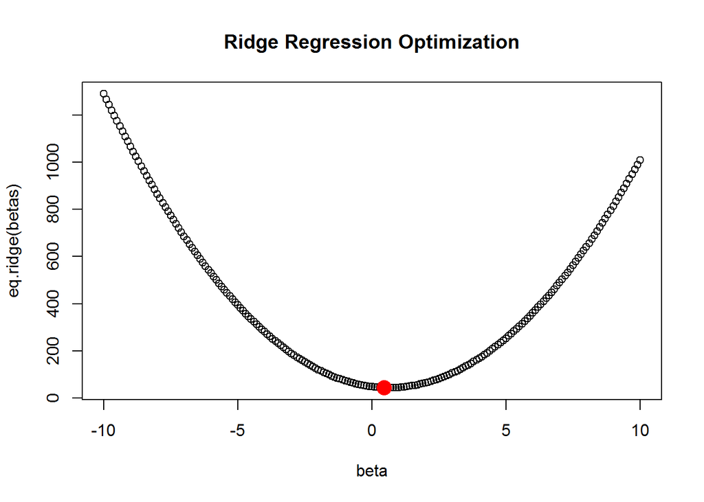

```r
betas <- seq(-10,10,0.1)
eq.ridge <- function(beta, y=7, lambda=10) (y-beta)^2 + lambda*beta^2
plot(betas, eq.ridge(betas), xlab="beta", main="Ridge Regression Optimization", pch=1)
points(5/(1+10), eq.ridge(7/(1+10)), pch=16, col="red", cex=2)
```

**Part b)**

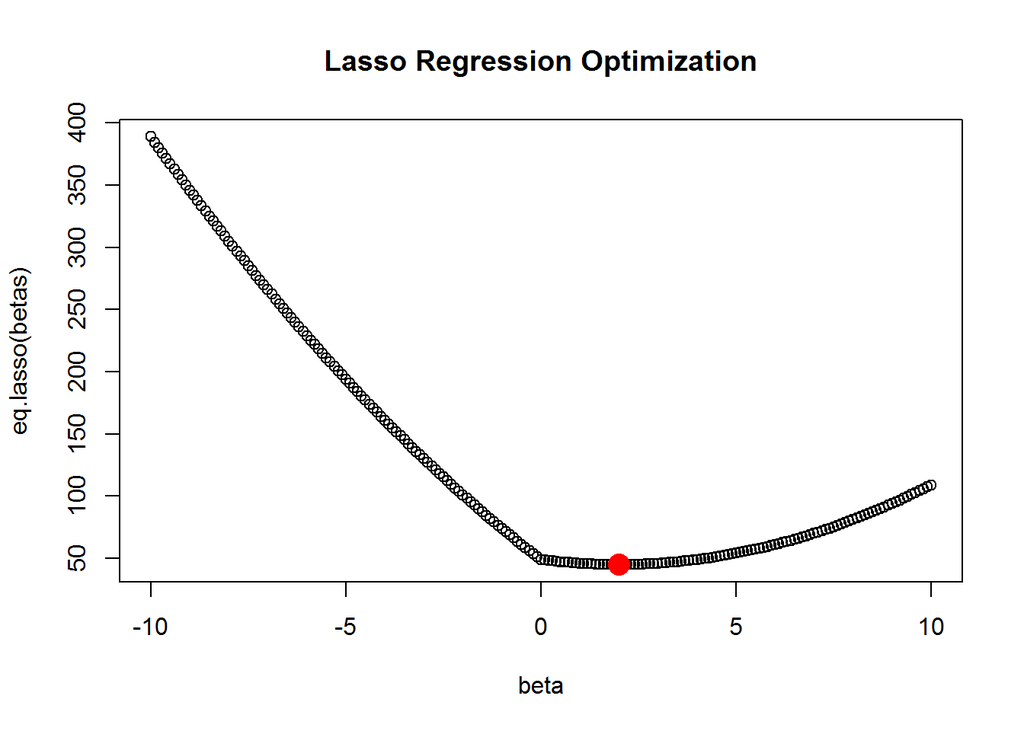

```r
betas <- seq(-10,10,0.1)
eq.lasso <- function(beta, y=7, lambda=10) (y-beta)^2 + lambda*abs(beta)
plot(betas, eq.lasso(betas), xlab="beta", main="Lasso Regression Optimization", pch=1)
points(7-10/2, eq.lasso(7-10/2), pch=16, col="red", cex=2)
```

> EXERCISE 7:

**Part a)**

[*… will come back to this. maybe.*]

**Part b)**

[*… will come back to this. maybe.*]

**Part c)**

[*… will come back to this. maybe.*]

**Part d)**

[*… will come back to this. maybe.*]

**Part e)**

[*… will come back to this. maybe.*]

## APPLIED

> EXERCISE 8:

**Part a)**

```r
set.seed(1)
X <- rnorm(100)
eps <- rnorm(100)
```

**Part b)**

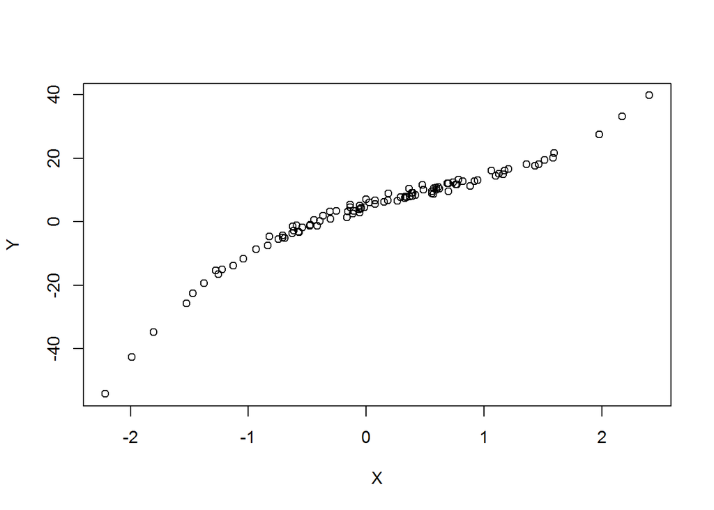

```r
Y <- 5 + 10*X - 3*X^2 + 2*X^3 + eps
plot(X,Y)
```

**Part c)**

```r
require(leaps)
regfit.full <- regsubsets(Y~poly(X,10,raw=T), data=data.frame(Y,X), nvmax=10)
(reg.summary <- summary(regfit.full))
```

```
## Subset selection object
## Call: regsubsets.formula(Y ~ poly(X, 10, raw = T), data = data.frame(Y,
##     X), nvmax = 10)
## 10 Variables  (and intercept)
##                        Forced in Forced out
## poly(X, 10, raw = T)1      FALSE      FALSE
## poly(X, 10, raw = T)2      FALSE      FALSE
## poly(X, 10, raw = T)3      FALSE      FALSE
## poly(X, 10, raw = T)4      FALSE      FALSE
## poly(X, 10, raw = T)5      FALSE      FALSE
## poly(X, 10, raw = T)6      FALSE      FALSE
## poly(X, 10, raw = T)7      FALSE      FALSE
## poly(X, 10, raw = T)8      FALSE      FALSE
## poly(X, 10, raw = T)9      FALSE      FALSE
## poly(X, 10, raw = T)10     FALSE      FALSE
```

[output cut: 57 more lines]

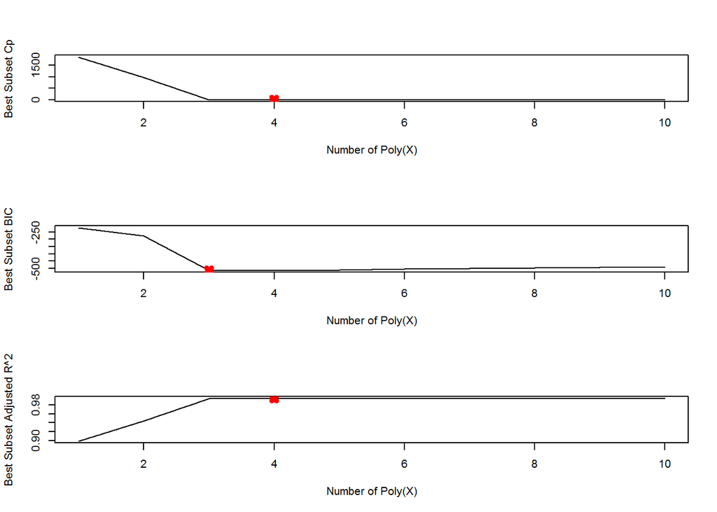

```r
par(mfrow=c(3,1))
min.cp <- which.min(reg.summary$cp)
plot(reg.summary$cp, xlab="Number of Poly(X)", ylab="Best Subset Cp", type="l")
points(min.cp, reg.summary$cp[min.cp], col="red", pch=4, lwd=5)
min.bic <- which.min(reg.summary$bic)
plot(reg.summary$bic, xlab="Number of Poly(X)", ylab="Best Subset BIC", type="l")
points(min.bic, reg.summary$bic[min.bic], col="red", pch=4, lwd=5)
min.adjr2 <- which.max(reg.summary$adjr2)
plot(reg.summary$adjr2, xlab="Number of Poly(X)", ylab="Best Subset Adjusted R^2", type="l")
points(min.adjr2, reg.summary$adjr2[min.adjr2], col="red", pch=4, lwd=5)
```

```r
coef(regfit.full, min.cp)
```

```
##           (Intercept) poly(X, 10, raw = T)1 poly(X, 10, raw = T)2
##            5.07200775           10.38745596           -3.15424359
## poly(X, 10, raw = T)3 poly(X, 10, raw = T)5
##            1.55797426            0.08072292
```

```r
coef(regfit.full, min.bic)
```

```
##           (Intercept) poly(X, 10, raw = T)1 poly(X, 10, raw = T)2
##              5.061507              9.975280             -3.123791
## poly(X, 10, raw = T)3
##              2.017639
```

```r
coef(regfit.full, min.adjr2)
```

```
##           (Intercept) poly(X, 10, raw = T)1 poly(X, 10, raw = T)2
##            5.07200775           10.38745596           -3.15424359
## poly(X, 10, raw = T)3 poly(X, 10, raw = T)5
##            1.55797426            0.08072292
```

**Part d)**

```r
# forward selection
regfit.fwd <- regsubsets(Y~poly(X,10,raw=T), data=data.frame(Y,X), nvmax=10)
(fwd.summary <- summary(regfit.fwd))
```

```
## Subset selection object
## Call: regsubsets.formula(Y ~ poly(X, 10, raw = T), data = data.frame(Y,
##     X), nvmax = 10)
## 10 Variables  (and intercept)
##                        Forced in Forced out
## poly(X, 10, raw = T)1      FALSE      FALSE
## poly(X, 10, raw = T)2      FALSE      FALSE
## poly(X, 10, raw = T)3      FALSE      FALSE
## poly(X, 10, raw = T)4      FALSE      FALSE
## poly(X, 10, raw = T)5      FALSE      FALSE
## poly(X, 10, raw = T)6      FALSE      FALSE
## poly(X, 10, raw = T)7      FALSE      FALSE
## poly(X, 10, raw = T)8      FALSE      FALSE
## poly(X, 10, raw = T)9      FALSE      FALSE
## poly(X, 10, raw = T)10     FALSE      FALSE
```

[output cut: 57 more lines]

```r
# backward selection
regfit.bwd <- regsubsets(Y~poly(X,10,raw=T), data=data.frame(Y,X), nvmax=10)
(bwd.summary <- summary(regfit.bwd))
```

```
## Subset selection object
## Call: regsubsets.formula(Y ~ poly(X, 10, raw = T), data = data.frame(Y,
##     X), nvmax = 10)
## 10 Variables  (and intercept)
##                        Forced in Forced out
## poly(X, 10, raw = T)1      FALSE      FALSE
## poly(X, 10, raw = T)2      FALSE      FALSE
## poly(X, 10, raw = T)3      FALSE      FALSE
## poly(X, 10, raw = T)4      FALSE      FALSE
## poly(X, 10, raw = T)5      FALSE      FALSE
## poly(X, 10, raw = T)6      FALSE      FALSE
## poly(X, 10, raw = T)7      FALSE      FALSE
## poly(X, 10, raw = T)8      FALSE      FALSE
## poly(X, 10, raw = T)9      FALSE      FALSE
## poly(X, 10, raw = T)10     FALSE      FALSE
```

[output cut: 57 more lines]

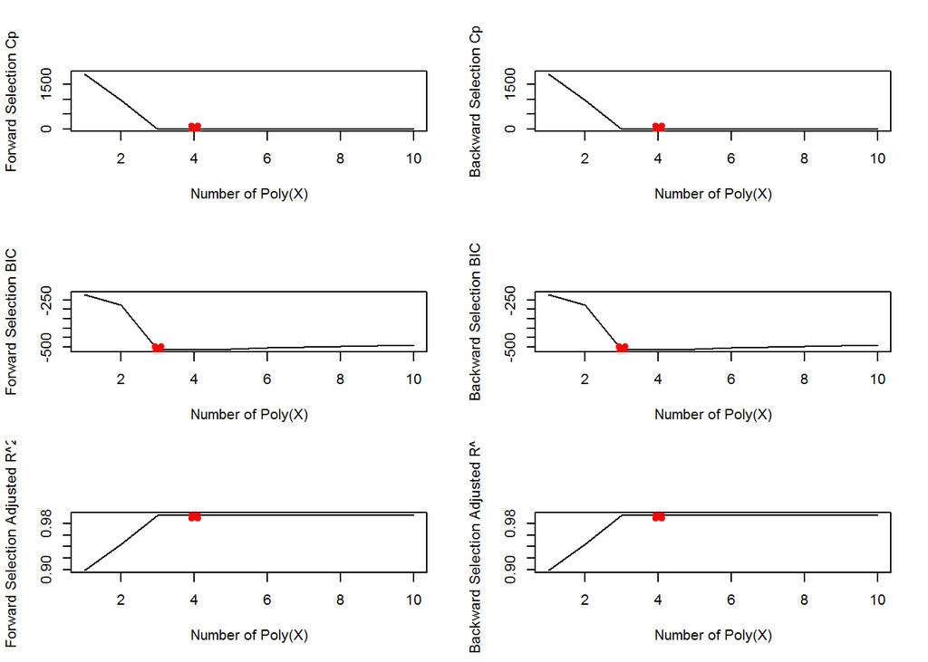

```r
par(mfrow=c(3,2))

min.cp <- which.min(fwd.summary$cp)
plot(fwd.summary$cp, xlab="Number of Poly(X)", ylab="Forward Selection Cp", type="l")
points(min.cp, fwd.summary$cp[min.cp], col="red", pch=4, lwd=5)

min.cp <- which.min(bwd.summary$cp)
plot(bwd.summary$cp, xlab="Number of Poly(X)", ylab="Backward Selection Cp", type="l")
points(min.cp, bwd.summary$cp[min.cp], col="red", pch=4, lwd=5)

min.bic <- which.min(fwd.summary$bic)
plot(fwd.summary$bic, xlab="Number of Poly(X)", ylab="Forward Selection BIC", type="l")
points(min.bic, fwd.summary$bic[min.bic], col="red", pch=4, lwd=5)

min.bic <- which.min(bwd.summary$bic)
plot(bwd.summary$bic, xlab="Number of Poly(X)", ylab="Backward Selection BIC", type="l")
points(min.bic, bwd.summary$bic[min.bic], col="red", pch=4, lwd=5)

min.adjr2 <- which.max(fwd.summary$adjr2)
plot(fwd.summary$adjr2, xlab="Number of Poly(X)", ylab="Forward Selection Adjusted R^2", type="l")
points(min.adjr2, fwd.summary$adjr2[min.adjr2], col="red", pch=4, lwd=5)

min.adjr2 <- which.max(bwd.summary$adjr2)
plot(bwd.summary$adjr2, xlab="Number of Poly(X)", ylab="Backward Selection Adjusted R^2", type="l")
points(min.adjr2, bwd.summary$adjr2[min.adjr2], col="red", pch=4, lwd=5)
```

```r
# coefficients of selected models
coef(regfit.fwd, which.min(fwd.summary$cp))
```

```
##           (Intercept) poly(X, 10, raw = T)1 poly(X, 10, raw = T)2
##            5.07200775           10.38745596           -3.15424359
## poly(X, 10, raw = T)3 poly(X, 10, raw = T)5
##            1.55797426            0.08072292
```

```r
coef(regfit.bwd, which.min(bwd.summary$cp))
```

```
##           (Intercept) poly(X, 10, raw = T)1 poly(X, 10, raw = T)2
##            5.07200775           10.38745596           -3.15424359
## poly(X, 10, raw = T)3 poly(X, 10, raw = T)5
##            1.55797426            0.08072292
```

```r
coef(regfit.fwd, which.min(fwd.summary$bic))
```

```
##           (Intercept) poly(X, 10, raw = T)1 poly(X, 10, raw = T)2
##              5.061507              9.975280             -3.123791
## poly(X, 10, raw = T)3
##              2.017639
```

```r
coef(regfit.bwd, which.min(bwd.summary$bic))
```

```
##           (Intercept) poly(X, 10, raw = T)1 poly(X, 10, raw = T)2
##              5.061507              9.975280             -3.123791
## poly(X, 10, raw = T)3
##              2.017639
```

```r
coef(regfit.fwd, which.max(fwd.summary$adjr2))
```

```
##           (Intercept) poly(X, 10, raw = T)1 poly(X, 10, raw = T)2
##            5.07200775           10.38745596           -3.15424359
## poly(X, 10, raw = T)3 poly(X, 10, raw = T)5
##            1.55797426            0.08072292
```

```r
coef(regfit.bwd, which.max(bwd.summary$adjr2))
```

```
##           (Intercept) poly(X, 10, raw = T)1 poly(X, 10, raw = T)2
##            5.07200775           10.38745596           -3.15424359
## poly(X, 10, raw = T)3 poly(X, 10, raw = T)5
##            1.55797426            0.08072292
```

Best subset, foward selection and backward selection all resulted in the same best models

**Part e)**

```r
require(glmnet)
xmat <- model.matrix(Y~poly(X,10,raw=T))[,-1]
lasso.mod <- cv.glmnet(xmat, Y, alpha=1)
(lambda <- lasso.mod$lambda.min)
```

```
## [1] 0.06392877
```

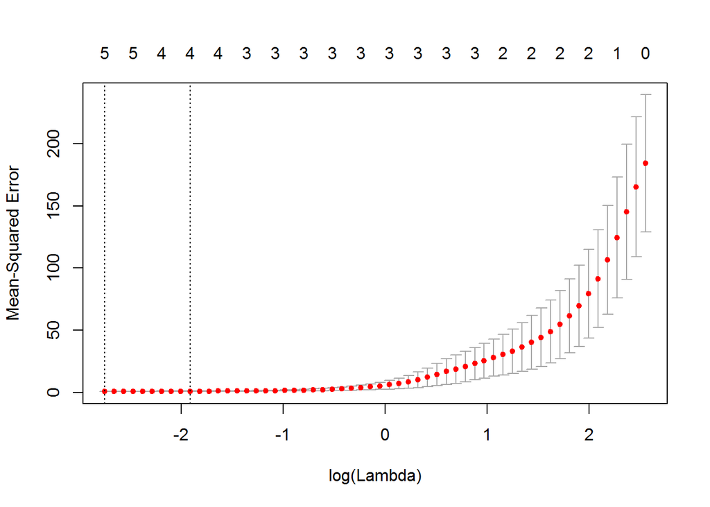

```r
par(mfrow=c(1,1))
plot(lasso.mod)
```

```r
predict(lasso.mod, s=lambda, type="coefficients")
```

```
## 11 x 1 sparse Matrix of class "dgCMatrix"
##                                    1
## (Intercept)             5.0197864204
## poly(X, 10, raw = T)1  10.1772066700
## poly(X, 10, raw = T)2  -3.0727099518
## poly(X, 10, raw = T)3   1.7336850893
## poly(X, 10, raw = T)4   .
## poly(X, 10, raw = T)5   0.0451934932
## poly(X, 10, raw = T)6   .
## poly(X, 10, raw = T)7   0.0002654849
## poly(X, 10, raw = T)8   .
## poly(X, 10, raw = T)9   .
## poly(X, 10, raw = T)10  .
```

**Part f)**

```r
Y2 <- 5 + 1.5*X^7 + eps

# best subset model selection
regfit.full <- regsubsets(Y2~poly(X,10,raw=T), data=data.frame(Y,X), nvmax=10)
par(mfrow=c(3,1))
(reg.summary <- summary(regfit.full))
```

```
## Subset selection object
## Call: regsubsets.formula(Y2 ~ poly(X, 10, raw = T), data = data.frame(Y,
##     X), nvmax = 10)
## 10 Variables  (and intercept)
##                        Forced in Forced out
## poly(X, 10, raw = T)1      FALSE      FALSE
## poly(X, 10, raw = T)2      FALSE      FALSE
## poly(X, 10, raw = T)3      FALSE      FALSE
## poly(X, 10, raw = T)4      FALSE      FALSE
## poly(X, 10, raw = T)5      FALSE      FALSE
## poly(X, 10, raw = T)6      FALSE      FALSE
## poly(X, 10, raw = T)7      FALSE      FALSE
## poly(X, 10, raw = T)8      FALSE      FALSE
## poly(X, 10, raw = T)9      FALSE      FALSE
## poly(X, 10, raw = T)10     FALSE      FALSE
```

[output cut: 57 more lines]

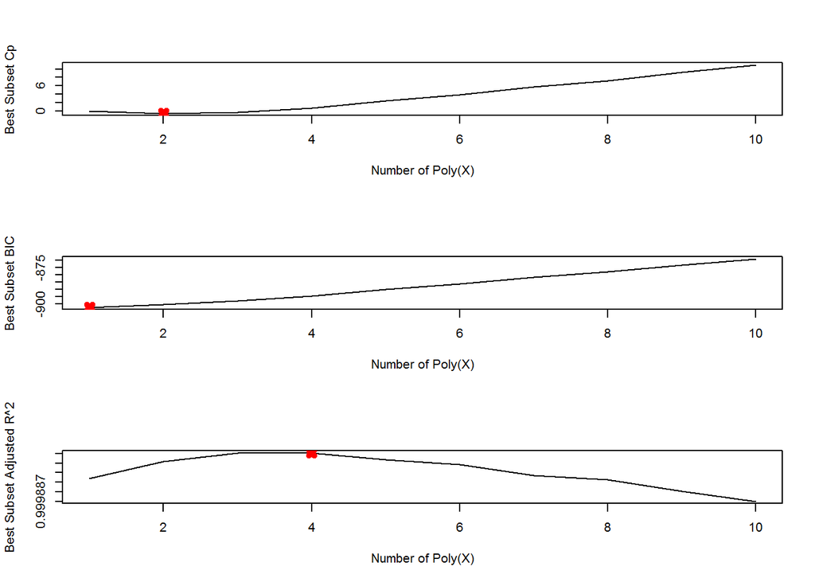

```r
min.cp <- which.min(reg.summary$cp)
plot(reg.summary$cp, xlab="Number of Poly(X)", ylab="Best Subset Cp", type="l")
points(min.cp, reg.summary$cp[min.cp], col="red", pch=4, lwd=5)
min.bic <- which.min(reg.summary$bic)
plot(reg.summary$bic, xlab="Number of Poly(X)", ylab="Best Subset BIC", type="l")
points(min.bic, reg.summary$bic[min.bic], col="red", pch=4, lwd=5)
min.adjr2 <- which.max(reg.summary$adjr2)
plot(reg.summary$adjr2, xlab="Number of Poly(X)", ylab="Best Subset Adjusted R^2", type="l")
points(min.adjr2, reg.summary$adjr2[min.adjr2], col="red", pch=4, lwd=5)
```

```r
coef(regfit.full, min.cp)
```

```
##           (Intercept) poly(X, 10, raw = T)2 poly(X, 10, raw = T)7
##             5.0704904            -0.1417084             1.5015552
```

```r
coef(regfit.full, min.bic)
```

```
##           (Intercept) poly(X, 10, raw = T)7
##               4.95894               1.50077
```

```r
coef(regfit.full, min.adjr2)
```

```
##           (Intercept) poly(X, 10, raw = T)1 poly(X, 10, raw = T)2
##             5.0762524             0.2914016            -0.1617671
## poly(X, 10, raw = T)3 poly(X, 10, raw = T)7
##            -0.2526527             1.5091338
```

```r
# lasso regression
xmat <- model.matrix(Y2~poly(X,10,raw=T))[,-1]
lasso.mod <- cv.glmnet(xmat, Y2, alpha=1)
(lambda <- lasso.mod$lambda.min)
```

```
## [1] 2.910056
```

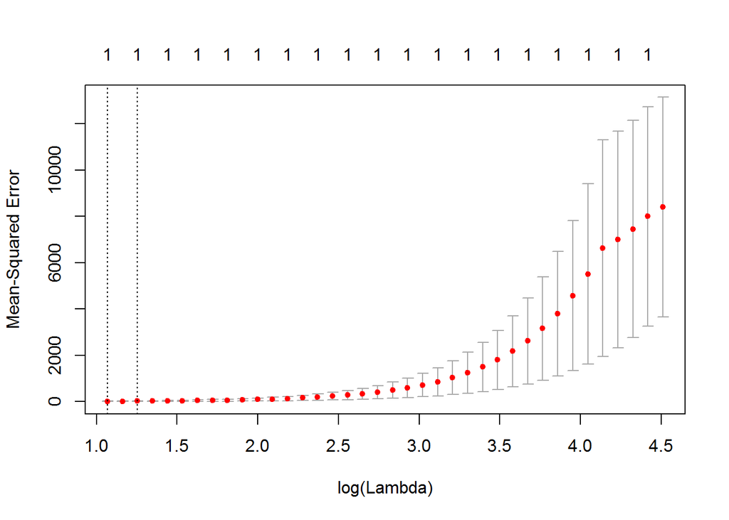

```r
par(mfrow=c(1,1))
plot(lasso.mod)
```

```r
predict(lasso.mod, s=lambda, type="coefficients")
```

```
## 11 x 1 sparse Matrix of class "dgCMatrix"
##                               1
## (Intercept)            5.161575
## poly(X, 10, raw = T)1  .
## poly(X, 10, raw = T)2  .
## poly(X, 10, raw = T)3  .
## poly(X, 10, raw = T)4  .
## poly(X, 10, raw = T)5  .
## poly(X, 10, raw = T)6  .
## poly(X, 10, raw = T)7  1.452757
## poly(X, 10, raw = T)8  .
## poly(X, 10, raw = T)9  .
## poly(X, 10, raw = T)10 .
```

Lasso selects the correct model but best subset diagnostics indicate using 1 to 4 predictors

> EXERCISE 9:

**Part a)**

```r
require(ISLR)
data(College)
set.seed(1)
trainid <- sample(1:nrow(College), nrow(College)/2)
train <- College[trainid,]
test <- College[-trainid,]
str(College)
```

```
## 'data.frame':    777 obs. of  18 variables:
##  $ Private    : Factor w/ 2 levels "No","Yes": 2 2 2 2 2 2 2 2 2 2 ...
##  $ Apps       : num  1660 2186 1428 417 193 ...
##  $ Accept     : num  1232 1924 1097 349 146 ...
##  $ Enroll     : num  721 512 336 137 55 158 103 489 227 172 ...
##  $ Top10perc  : num  23 16 22 60 16 38 17 37 30 21 ...
##  $ Top25perc  : num  52 29 50 89 44 62 45 68 63 44 ...
##  $ F.Undergrad: num  2885 2683 1036 510 249 ...
##  $ P.Undergrad: num  537 1227 99 63 869 ...
##  $ Outstate   : num  7440 12280 11250 12960 7560 ...
##  $ Room.Board : num  3300 6450 3750 5450 4120 ...
##  $ Books      : num  450 750 400 450 800 500 500 450 300 660 ...
##  $ Personal   : num  2200 1500 1165 875 1500 ...
##  $ PhD        : num  70 29 53 92 76 67 90 89 79 40 ...
##  $ Terminal   : num  78 30 66 97 72 73 93 100 84 41 ...
##  $ S.F.Ratio  : num  18.1 12.2 12.9 7.7 11.9 9.4 11.5 13.7 11.3 11.5 ...
##  $ perc.alumni: num  12 16 30 37 2 11 26 37 23 15 ...
##  $ Expend     : num  7041 10527 8735 19016 10922 ...
##  $ Grad.Rate  : num  60 56 54 59 15 55 63 73 80 52 ...
```

**Part b)**

```r
fit.lm <- lm(Apps~., data=train)
pred.lm <- predict(fit.lm, test)
(err.lm <- mean((test$Apps - pred.lm)^2))  # test error
```

```
## [1] 1108531
```

**Part c)**

```r
require(glmnet)
xmat.train <- model.matrix(Apps~., data=train)[,-1]
xmat.test <- model.matrix(Apps~., data=test)[,-1]
fit.ridge <- cv.glmnet(xmat.train, train$Apps, alpha=0)
(lambda <- fit.ridge$lambda.min)  # optimal lambda
```

```
## [1] 450.7435
```

```r
pred.ridge <- predict(fit.ridge, s=lambda, newx=xmat.test)
(err.ridge <- mean((test$Apps - pred.ridge)^2))  # test error
```

```
## [1] 1037616
```

**Part d)**

```r
require(glmnet)
xmat.train <- model.matrix(Apps~., data=train)[,-1]
xmat.test <- model.matrix(Apps~., data=test)[,-1]
fit.lasso <- cv.glmnet(xmat.train, train$Apps, alpha=1)
(lambda <- fit.lasso$lambda.min)  # optimal lambda
```

```
## [1] 29.65591
```

```r
pred.lasso <- predict(fit.lasso, s=lambda, newx=xmat.test)
(err.lasso <- mean((test$Apps - pred.lasso)^2))  # test error
```

```
## [1] 1025248
```

```r
coef.lasso <- predict(fit.lasso, type="coefficients", s=lambda)[1:ncol(College),]
coef.lasso[coef.lasso != 0]
```

```
##   (Intercept)    PrivateYes        Accept        Enroll     Top10perc
## -4.514223e+02 -4.814352e+02  1.535012e+00 -4.035455e-01  4.668170e+01
##     Top25perc   F.Undergrad      Outstate    Room.Board           PhD
## -7.091364e+00 -3.426988e-03 -5.020064e-02  1.851610e-01 -3.849885e+00
##      Terminal   perc.alumni        Expend     Grad.Rate
## -3.443747e+00 -2.117870e+00  3.192846e-02  2.695730e+00
```

```r
length(coef.lasso[coef.lasso != 0])
```

```
## [1] 14
```

**Part e)**

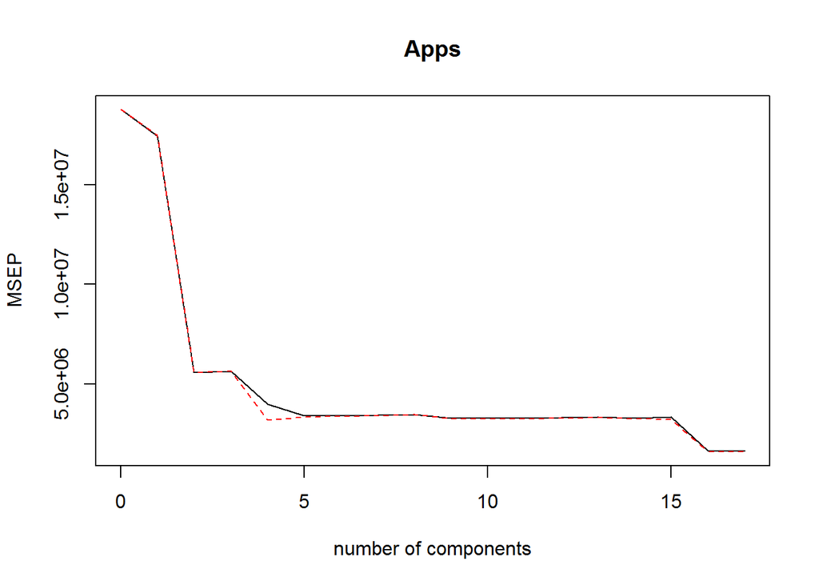

```r
require(pls)
set.seed(1)
fit.pcr <- pcr(Apps~., data=train, scale=TRUE, validation="CV")
validationplot(fit.pcr, val.type="MSEP")
```

```r
summary(fit.pcr)
```

```
## Data:    X dimension: 388 17
##  Y dimension: 388 1
## Fit method: svdpc
## Number of components considered: 17
##
## VALIDATION: RMSEP
## Cross-validated using 10 random segments.
##        (Intercept)  1 comps  2 comps  3 comps  4 comps  5 comps  6 comps
## CV            4335     4179     2364     2374     1996     1844     1845
## adjCV         4335     4182     2360     2374     1788     1831     1838
##        7 comps  8 comps  9 comps  10 comps  11 comps  12 comps  13 comps
## CV        1850     1863     1809      1809      1812      1815      1825
## adjCV     1844     1857     1801      1800      1804      1808      1817
##        14 comps  15 comps  16 comps  17 comps
## CV         1810      1823      1273      1281
## adjCV      1806      1789      1260      1268
##
## TRAINING: % variance explained
##       1 comps  2 comps  3 comps  4 comps  5 comps  6 comps  7 comps
## X      31.216    57.68    64.73    70.55    76.33    81.30    85.01
## Apps    6.976    71.47    71.58    83.32    83.44    83.45    83.46
##       8 comps  9 comps  10 comps  11 comps  12 comps  13 comps  14 comps
## X       88.40    91.16     93.36     95.38     96.94     97.96     98.76
## Apps    83.47    84.53     84.86     84.98     84.98     84.99     85.24
##       15 comps  16 comps  17 comps
## X        99.40     99.87    100.00
## Apps     90.87     93.93     93.97
```

```r
pred.pcr <- predict(fit.pcr, test, ncomp=16)  # min Cv at M=16
(err.pcr <- mean((test$Apps - pred.pcr)^2))  # test error
```

```
## [1] 1166897
```

**Part f)**

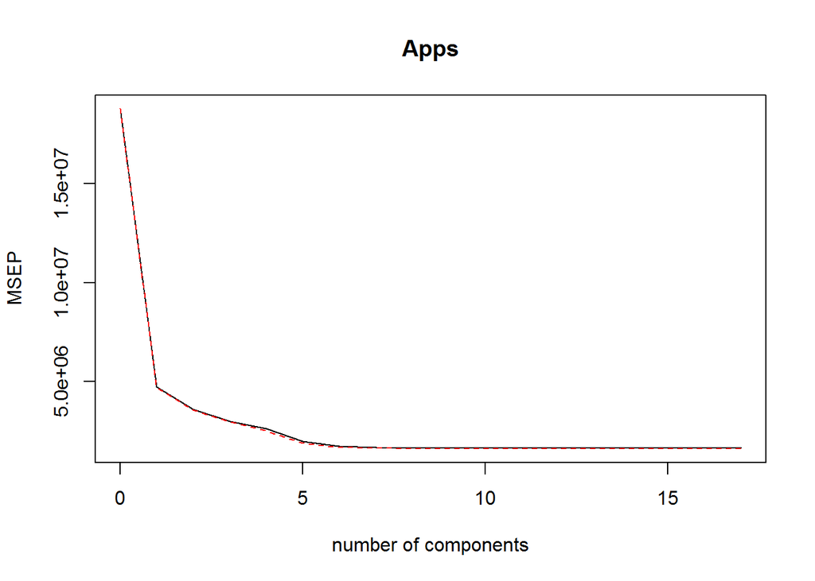

```r
require(pls)
set.seed(1)
fit.pls <- plsr(Apps~., data=train, scale=TRUE, validation="CV")
validationplot(fit.pls, val.type="MSEP")
```

```r
summary(fit.pls)
```

```
## Data:    X dimension: 388 17
##  Y dimension: 388 1
## Fit method: kernelpls
## Number of components considered: 17
##
## VALIDATION: RMSEP
## Cross-validated using 10 random segments.
##        (Intercept)  1 comps  2 comps  3 comps  4 comps  5 comps  6 comps
## CV            4335     2176     1893     1725     1613     1406     1312
## adjCV         4335     2171     1884     1715     1578     1375     1295
##        7 comps  8 comps  9 comps  10 comps  11 comps  12 comps  13 comps
## CV        1297     1285     1280      1278      1279      1282      1281
## adjCV     1281     1271     1267      1265      1266      1269      1268
##        14 comps  15 comps  16 comps  17 comps
## CV         1281      1281      1281      1281
## adjCV      1267      1267      1268      1268
##
## TRAINING: % variance explained
##       1 comps  2 comps  3 comps  4 comps  5 comps  6 comps  7 comps
## X       26.91    43.08    63.26    65.16    68.50    73.75    76.10
## Apps    76.64    83.93    87.14    91.90    93.49    93.85    93.91
##       8 comps  9 comps  10 comps  11 comps  12 comps  13 comps  14 comps
## X       79.03    81.76     85.41     89.03     91.38     93.31     95.43
## Apps    93.94    93.96     93.96     93.96     93.97     93.97     93.97
##       15 comps  16 comps  17 comps
## X        97.41     98.78    100.00
## Apps     93.97     93.97     93.97
```

```r
pred.pls <- predict(fit.pls, test, ncomp=10)  # min Cv at M=10
(err.pls <- mean((test$Apps - pred.pls)^2))  # test error
```

```
## [1] 1134531
```

**Part g)**

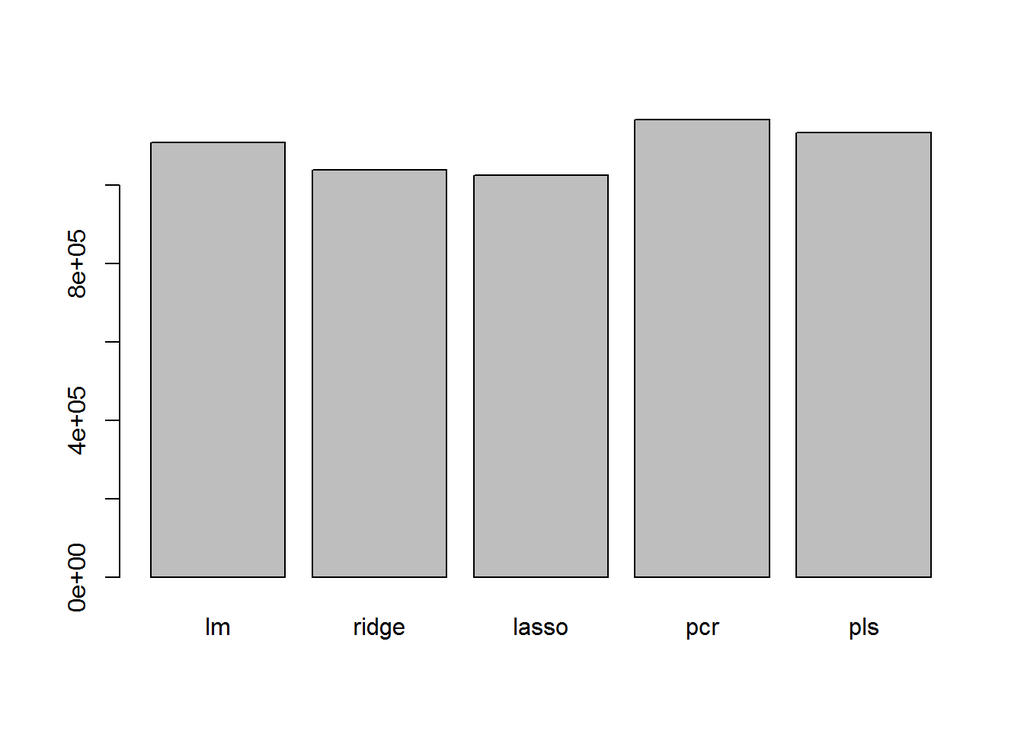

```r
err.all <- c(err.lm, err.ridge, err.lasso, err.pcr, err.pls)
names(err.all) <- c("lm", "ridge", "lasso", "pcr", "pls")
barplot(err.all )
```

The test errors aren’t much different. The ridge and lasso seem to perform slightly better while the PCR/PLS don’t show any improvement from the full linear regression model.

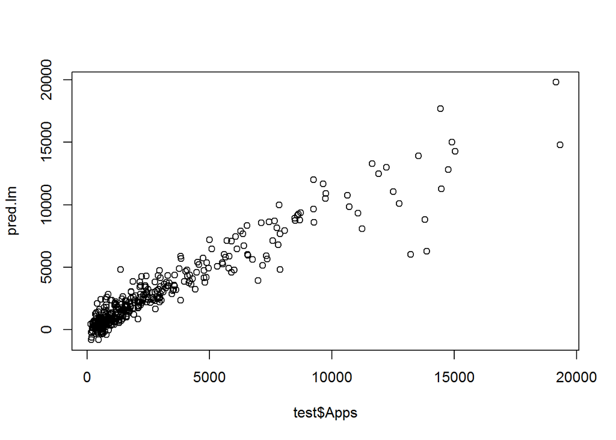

```r
plot(test$Apps, pred.lm)
```

> EXERCISE 10:

**Part a)**

```r
set.seed(1)
eps <- rnorm(1000)
xmat <- matrix(rnorm(1000*20), ncol=20)
betas <- sample(-5:5, 20, replace=TRUE)
betas[c(3,6,7,10,13,17)] <- 0
betas
```

```
##  [1]  2  3  0  5  1  0  0 -3  3  0  4  3  0 -4 -4 -2  0  0 -5  2
```

```r
y <- xmat %*% betas + eps
```

**Part b)**

```r
set.seed(1)
trainid <- sample(1:1000, 100, replace=FALSE)
xmat.train <- xmat[trainid,]
xmat.test <- xmat[-trainid,]
y.train <- y[trainid,]
y.test <- y[-trainid,]
train <- data.frame(y=y.train, xmat.train)
test <- data.frame(y=y.test, xmat.test)
```

**Part c)**

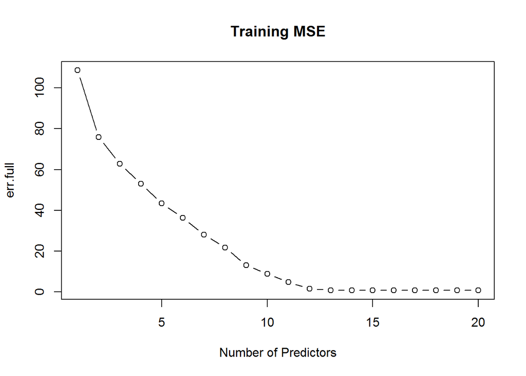

```r
require(leaps)

# predict function from chapter 6 labs
predict.regsubsets <- function(object, newdata, id, ...){
  form <- as.formula(object$call[[2]])
  mat <- model.matrix(form, newdata)
  coefi <- coef(object, id=id)
  xvars <- names(coefi)
  mat[,xvars]%*%coefi
}

regfit.full <- regsubsets(y~., data=train, nvmax=20)
err.full <- rep(NA, 20)
for(i in 1:20) {
  pred.full <- predict(regfit.full, train, id=i)
  err.full[i] <- mean((train$y - pred.full)^2)
}
plot(1:20, err.full, type="b", main="Training MSE", xlab="Number of Predictors")
```

```r
which.min(err.full)  # min for train error should be at max pred count
```

```
## [1] 20
```

**Part d)**

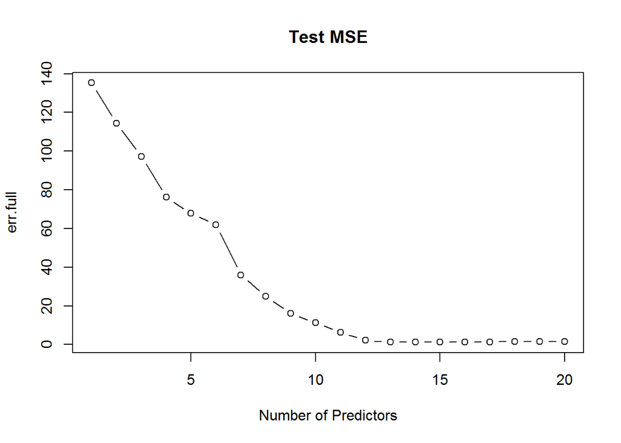

```r
err.full <- rep(NA, 20)
for(i in 1:20) {
  pred.full <- predict(regfit.full, test, id=i)
  err.full[i] <- mean((test$y - pred.full)^2)
}
plot(1:20, err.full, type="b", main="Test MSE", xlab="Number of Predictors")
```

**Part e)**

```r
which.min(err.full)  # optimal number of predictors from best subset
```

```
## [1] 13
```

**Part f)**

```r
(coef.best <- coef(regfit.full, id=which.min(err.full)))
```

```
## (Intercept)          X1          X2          X4          X5          X8
##  -0.1732881   2.0010181   3.0865262   4.9303510   0.9812254  -2.9307495
##          X9         X11         X12         X14         X15         X16
##   3.0238521   3.8272702   3.0607539  -3.9277547  -4.0459157  -1.7658311
##         X19         X20
##  -4.7888341   2.2134924
```

```r
betas[betas != 0]
```

```
##  [1]  2  3  5  1 -3  3  4  3 -4 -4 -2 -5  2
```

```r
names(betas) <- paste0("X", 1:20)
merge(data.frame(beta=names(betas),betas), data.frame(beta=names(coef.best),coef.best), all.x=T, sort=F)
```

```
##    beta betas  coef.best
## 1    X1     2  2.0010181
## 2    X2     3  3.0865262
## 3    X4     5  4.9303510
## 4    X5     1  0.9812254
## 5    X8    -3 -2.9307495
## 6    X9     3  3.0238521
## 7   X11     4  3.8272702
## 8   X12     3  3.0607539
## 9   X14    -4 -3.9277547
## 10  X15    -4 -4.0459157
## 11  X16    -2 -1.7658311
## 12  X19    -5 -4.7888341
## 13  X20     2  2.2134924
## 14  X13     0         NA
## 15   X6     0         NA
## 16   X3     0         NA
## 17  X17     0         NA
## 18  X10     0         NA
## 19   X7     0         NA
## 20  X18     0         NA
```

The best subset model selected all the correct predictors

**Part g)**

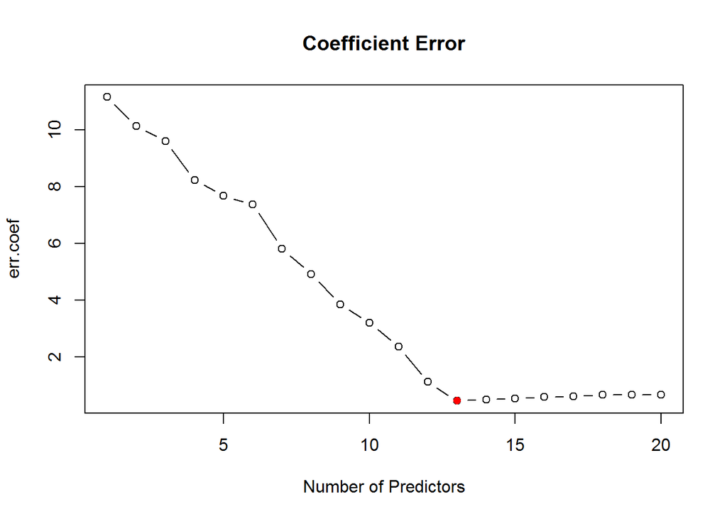

```r
err.coef <- rep(NA, 20)
for(i in 1:20) {
  coef.i <- coef(regfit.full, id=i)
  df.err <- merge(data.frame(beta=names(betas),betas), data.frame(beta=names(coef.i),coef.i), all.x=T)
  df.err[is.na(df.err[,3]),3] <- 0
  err.coef[i] <- sqrt(sum((df.err[,2] - df.err[,3])^2))
}
plot(1:20, err.coef, type="b", main="Coefficient Error", xlab="Number of Predictors")
points(which.min(err.coef), err.coef[which.min(err.coef)], col="red", pch=16)
```

The coefficient error plot shows a very similar plot to the test error plot

> EXERCISE 11:

**Part a)**

```r
require(leaps)   # forward and backward selection
require(glmnet)  # ridge and lasso
require(MASS)    # Boston data set
data(Boston)

# split data into training and test sets
set.seed(1)
trainid <- sample(1:nrow(Boston), nrow(Boston)/2)
train <- Boston[trainid,]
test <- Boston[-trainid,]
xmat.train <- model.matrix(crim~., data=train)[,-1]
xmat.test <- model.matrix(crim~., data=test)[,-1]
str(Boston)
```

```
## 'data.frame':    506 obs. of  14 variables:
##  $ crim   : num  0.00632 0.02731 0.02729 0.03237 0.06905 ...
##  $ zn     : num  18 0 0 0 0 0 12.5 12.5 12.5 12.5 ...
##  $ indus  : num  2.31 7.07 7.07 2.18 2.18 2.18 7.87 7.87 7.87 7.87 ...
##  $ chas   : int  0 0 0 0 0 0 0 0 0 0 ...
##  $ nox    : num  0.538 0.469 0.469 0.458 0.458 0.458 0.524 0.524 0.524 0.524 ...
##  $ rm     : num  6.58 6.42 7.18 7 7.15 ...
##  $ age    : num  65.2 78.9 61.1 45.8 54.2 58.7 66.6 96.1 100 85.9 ...
##  $ dis    : num  4.09 4.97 4.97 6.06 6.06 ...
##  $ rad    : int  1 2 2 3 3 3 5 5 5 5 ...
##  $ tax    : num  296 242 242 222 222 222 311 311 311 311 ...
##  $ ptratio: num  15.3 17.8 17.8 18.7 18.7 18.7 15.2 15.2 15.2 15.2 ...
##  $ black  : num  397 397 393 395 397 ...
##  $ lstat  : num  4.98 9.14 4.03 2.94 5.33 ...
##  $ medv   : num  24 21.6 34.7 33.4 36.2 28.7 22.9 27.1 16.5 18.9 ...
```

```r
# ridge regression model
fit.ridge <- cv.glmnet(xmat.train, train$crim, alpha=0)
(lambda <- fit.ridge$lambda.min)  # optimal lambda
```

```
## [1] 0.5982585
```

```r
pred.ridge <- predict(fit.ridge, s=lambda, newx=xmat.test)
(err.ridge <- mean((test$crim - pred.ridge)^2))  # test error
```

```
## [1] 38.36353
```

```r
predict(fit.ridge, s=lambda, type="coefficients")
```

```
## 14 x 1 sparse Matrix of class "dgCMatrix"
##                        1
## (Intercept)  4.429222285
## zn           0.036521710
## indus       -0.061214283
## chas        -0.775621731
## nox         -8.045252067
## rm           1.179585530
## age          0.005683303
## dis         -0.884805550
## rad          0.429755276
## tax          0.003261068
## ptratio     -0.169564880
## black       -0.004036776
## lstat        0.193028502
## medv        -0.171441090
```

```r
# lasso regression model
fit.lasso <- cv.glmnet(xmat.train, train$crim, alpha=1)
(lambda <- fit.lasso$lambda.min)  # optimal lambda
```

```
## [1] 0.2530181
```

```r
pred.lasso <- predict(fit.lasso, s=lambda, newx=xmat.test)
(err.lasso <- mean((test$crim - pred.lasso)^2))  # test error
```

```
## [1] 38.4593
```

```r
predict(fit.lasso, s=lambda, type="coefficients")
```

```
## 14 x 1 sparse Matrix of class "dgCMatrix"
##                        1
## (Intercept) -1.803083100
## zn           0.017767800
## indus        .
## chas        -0.266407052
## nox          .
## rm           0.510067274
## age          .
## dis         -0.377582057
## rad          0.457627436
## tax          .
## ptratio      .
## black       -0.002413684
## lstat        0.159515883
## medv        -0.093917991
```

```r
# predict function from chapter 6 labs
predict.regsubsets <- function(object, newdata, id, ...){
  form <- as.formula(object$call[[2]])
  mat <- model.matrix(form, newdata)
  coefi <- coef(object, id=id)
  xvars <- names(coefi)
  mat[,xvars]%*%coefi
}

# forward selection
fit.fwd <- regsubsets(crim~., data=train, nvmax=ncol(Boston)-1)
(fwd.summary <- summary(fit.fwd))
```

```
## Subset selection object
## Call: regsubsets.formula(crim ~ ., data = train, nvmax = ncol(Boston) -
##     1)
## 13 Variables  (and intercept)
##         Forced in Forced out
## zn          FALSE      FALSE
## indus       FALSE      FALSE
## chas        FALSE      FALSE
## nox         FALSE      FALSE
## rm          FALSE      FALSE
## age         FALSE      FALSE
## dis         FALSE      FALSE
## rad         FALSE      FALSE
## tax         FALSE      FALSE
## ptratio     FALSE      FALSE
## black       FALSE      FALSE
## lstat       FALSE      FALSE
## medv        FALSE      FALSE
## 1 subsets of each size up to 13
## Selection Algorithm: exhaustive
##           zn  indus chas nox rm  age dis rad tax ptratio black lstat medv
## 1  ( 1 )  " " " "   " "  " " " " " " " " "*" " " " "     " "   " "   " "
## 2  ( 1 )  " " " "   " "  " " " " " " " " "*" " " " "     " "   "*"   " "
## 3  ( 1 )  " " " "   " "  " " "*" " " " " "*" " " " "     " "   "*"   " "
## 4  ( 1 )  "*" " "   " "  " " " " " " "*" "*" " " " "     " "   " "   "*"
## 5  ( 1 )  "*" " "   " "  "*" " " " " "*" "*" " " " "     " "   " "   "*"
## 6  ( 1 )  "*" " "   " "  "*" "*" " " "*" "*" " " " "     " "   " "   "*"
## 7  ( 1 )  "*" " "   " "  "*" "*" " " "*" "*" " " " "     " "   "*"   "*"
## 8  ( 1 )  "*" " "   " "  "*" "*" " " "*" "*" " " "*"     " "   "*"   "*"
## 9  ( 1 )  "*" " "   " "  "*" "*" " " "*" "*" "*" "*"     " "   "*"   "*"
## 10  ( 1 ) "*" " "   "*"  "*" "*" " " "*" "*" "*" "*"     " "   "*"   "*"
## 11  ( 1 ) "*" " "   "*"  "*" "*" " " "*" "*" "*" "*"     "*"   "*"   "*"
## 12  ( 1 ) "*" " "   "*"  "*" "*" "*" "*" "*" "*" "*"     "*"   "*"   "*"
## 13  ( 1 ) "*" "*"   "*"  "*" "*" "*" "*" "*" "*" "*"     "*"   "*"   "*"
```

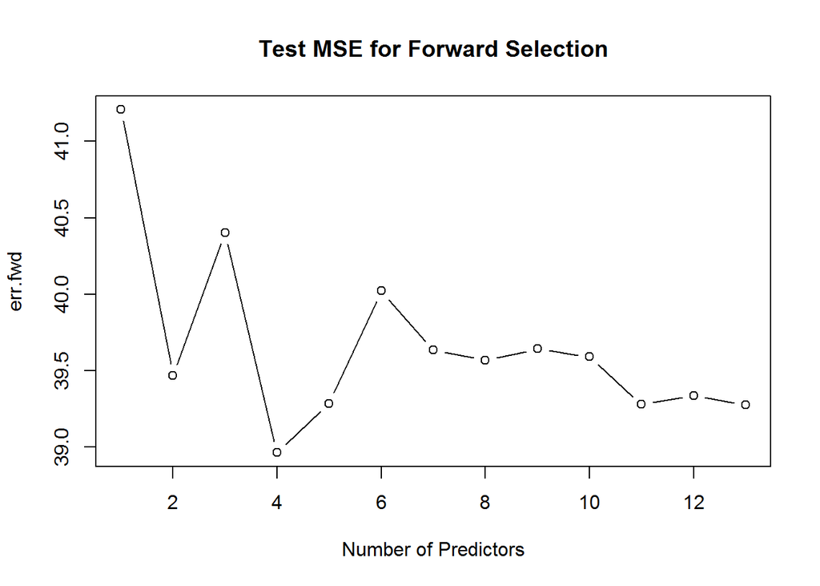

```r
err.fwd <- rep(NA, ncol(Boston)-1)
for(i in 1:(ncol(Boston)-1)) {
  pred.fwd <- predict(fit.fwd, test, id=i)
  err.fwd[i] <- mean((test$crim - pred.fwd)^2)
}
plot(err.fwd, type="b", main="Test MSE for Forward Selection", xlab="Number of Predictors")
```

```r
which.min(err.fwd)
```

```
## [1] 4
```

```r
# backward selection
fit.bwd <- regsubsets(crim~., data=train, nvmax=ncol(Boston)-1)
(bwd.summary <- summary(fit.bwd))
```

```
## Subset selection object
## Call: regsubsets.formula(crim ~ ., data = train, nvmax = ncol(Boston) -
##     1)
## 13 Variables  (and intercept)
##         Forced in Forced out
## zn          FALSE      FALSE
## indus       FALSE      FALSE
## chas        FALSE      FALSE
## nox         FALSE      FALSE
## rm          FALSE      FALSE
## age         FALSE      FALSE
## dis         FALSE      FALSE
## rad         FALSE      FALSE
## tax         FALSE      FALSE
## ptratio     FALSE      FALSE
## black       FALSE      FALSE
## lstat       FALSE      FALSE
## medv        FALSE      FALSE
## 1 subsets of each size up to 13
## Selection Algorithm: exhaustive
##           zn  indus chas nox rm  age dis rad tax ptratio black lstat medv
## 1  ( 1 )  " " " "   " "  " " " " " " " " "*" " " " "     " "   " "   " "
## 2  ( 1 )  " " " "   " "  " " " " " " " " "*" " " " "     " "   "*"   " "
## 3  ( 1 )  " " " "   " "  " " "*" " " " " "*" " " " "     " "   "*"   " "
## 4  ( 1 )  "*" " "   " "  " " " " " " "*" "*" " " " "     " "   " "   "*"
## 5  ( 1 )  "*" " "   " "  "*" " " " " "*" "*" " " " "     " "   " "   "*"
## 6  ( 1 )  "*" " "   " "  "*" "*" " " "*" "*" " " " "     " "   " "   "*"
## 7  ( 1 )  "*" " "   " "  "*" "*" " " "*" "*" " " " "     " "   "*"   "*"
## 8  ( 1 )  "*" " "   " "  "*" "*" " " "*" "*" " " "*"     " "   "*"   "*"
## 9  ( 1 )  "*" " "   " "  "*" "*" " " "*" "*" "*" "*"     " "   "*"   "*"
## 10  ( 1 ) "*" " "   "*"  "*" "*" " " "*" "*" "*" "*"     " "   "*"   "*"
## 11  ( 1 ) "*" " "   "*"  "*" "*" " " "*" "*" "*" "*"     "*"   "*"   "*"
## 12  ( 1 ) "*" " "   "*"  "*" "*" "*" "*" "*" "*" "*"     "*"   "*"   "*"
## 13  ( 1 ) "*" "*"   "*"  "*" "*" "*" "*" "*" "*" "*"     "*"   "*"   "*"
```

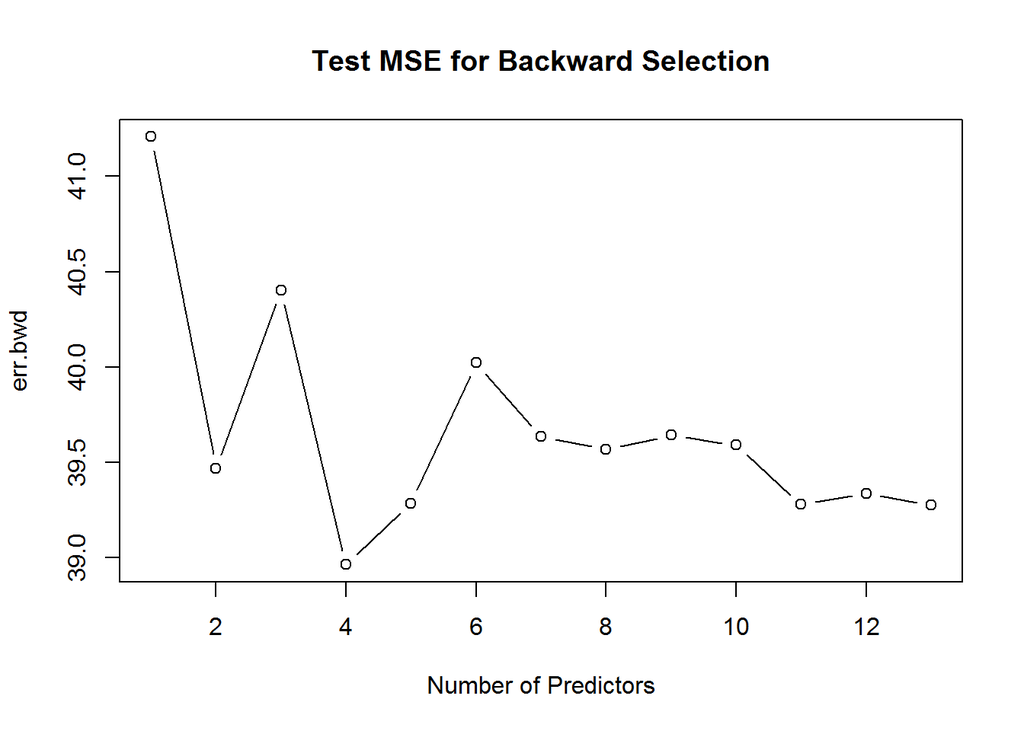

```r
err.bwd <- rep(NA, ncol(Boston)-1)
for(i in 1:(ncol(Boston)-1)) {
  pred.bwd <- predict(fit.bwd, test, id=i)
  err.bwd[i] <- mean((test$crim - pred.bwd)^2)
}
plot(err.bwd, type="b", main="Test MSE for Backward Selection", xlab="Number of Predictors")
```

```r
which.min(err.bwd)
```

```
## [1] 4
```

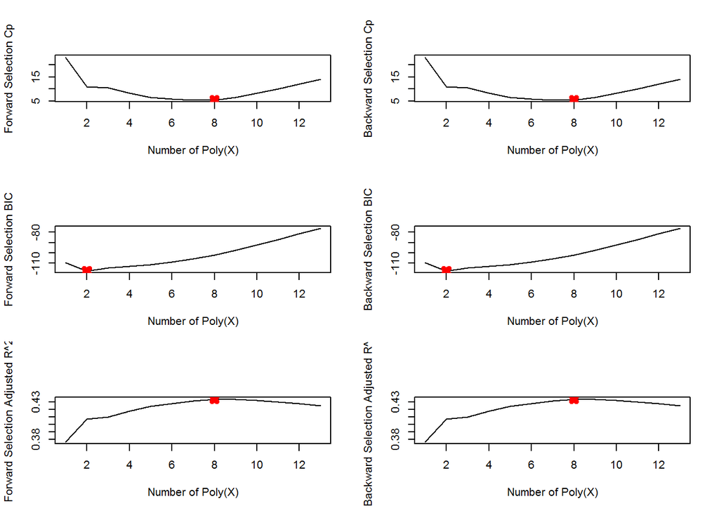

```r
par(mfrow=c(3,2))

min.cp <- which.min(fwd.summary$cp)
plot(fwd.summary$cp, xlab="Number of Poly(X)", ylab="Forward Selection Cp", type="l")
points(min.cp, fwd.summary$cp[min.cp], col="red", pch=4, lwd=5)

min.cp <- which.min(bwd.summary$cp)
plot(bwd.summary$cp, xlab="Number of Poly(X)", ylab="Backward Selection Cp", type="l")
points(min.cp, bwd.summary$cp[min.cp], col="red", pch=4, lwd=5)

min.bic <- which.min(fwd.summary$bic)
plot(fwd.summary$bic, xlab="Number of Poly(X)", ylab="Forward Selection BIC", type="l")
points(min.bic, fwd.summary$bic[min.bic], col="red", pch=4, lwd=5)

min.bic <- which.min(bwd.summary$bic)
plot(bwd.summary$bic, xlab="Number of Poly(X)", ylab="Backward Selection BIC", type="l")
points(min.bic, bwd.summary$bic[min.bic], col="red", pch=4, lwd=5)

min.adjr2 <- which.max(fwd.summary$adjr2)
plot(fwd.summary$adjr2, xlab="Number of Poly(X)", ylab="Forward Selection Adjusted R^2", type="l")
points(min.adjr2, fwd.summary$adjr2[min.adjr2], col="red", pch=4, lwd=5)

min.adjr2 <- which.max(bwd.summary$adjr2)
plot(bwd.summary$adjr2, xlab="Number of Poly(X)", ylab="Backward Selection Adjusted R^2", type="l")
points(min.adjr2, bwd.summary$adjr2[min.adjr2], col="red", pch=4, lwd=5)
```

**Part b)**

```r
err.ridge
```

```
## [1] 38.36353
```

```r
err.lasso
```

```
## [1] 38.4593
```

```r
err.fwd
```

```
##  [1] 41.20712 39.46705 40.40271 38.96427 39.28537 40.02194 39.63462
##  [8] 39.56733 39.64198 39.59028 39.27845 39.33711 39.27592
```

```r
err.bwd
```

```
##  [1] 41.20712 39.46705 40.40271 38.96427 39.28537 40.02194 39.63462
##  [8] 39.56733 39.64198 39.59028 39.27845 39.33711 39.27592
```

Probably choose the lasso model because its test MSE is close to best and eliminates some predictors to reduce model complexity

**Part c)**

No because not all the predictors add much value to the model